# Report on: Project of the Coursera Class “Machine Learning” of the Data Science Specialization

## Report on: Project of the Coursera Class “Machine Learning” of the Data Science Specialization

(Florian Sobieczky - October 22, 2015)

Overview: Using the data sets from Velloso et. al. about Qualitative Activity Recognition of Weight Lifting Exercises', a prediction algorithm is presented using standard methods from the caret package in R.

Velloso, E.; Bulling, A.; Gellersen, H.; Ugulino, W.; Fuks, H. Qualitative Activity Recognition of Weight Lifting Exercises. Proceedings of 4th International Conference in Cooperation with SIGCHI (Augmented Human '13) . Stuttgart, Germany: ACM SIGCHI, 2013.

Load Libraries

Data import and preparation:

We will consider training data from the project description:

```r
trainD<-read.csv("pml-training.csv");  # training data
testD<-read.csv("pml-testing.csv");   # testing data
```

## Goal

The exercise states that:

The goal of your project is to predict the manner in which \“they did the exercise. This is the 'classe' variable in the training set. \”

In other words, the question is for a prediction model for the classe variable, given any other variable as a predictor.

## Data Exploration

To first explore the data set and spot good predictor variables (so as not having to use all 159 variables as predictors), we use feature plot to find variables for which the measured coordinates decompose well into the different classes (A,B,C,D, or E).

The following command is repeated with different groups of subcolumns. The following group (1,7,10,15) (X, num_window, yaw_belt, skewness_roll_belt) is particularly instructive:

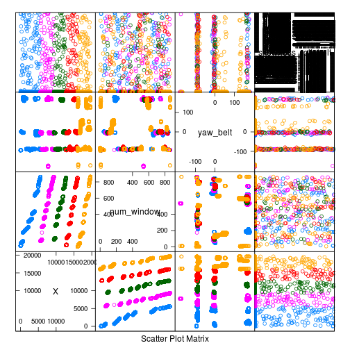

```r
featurePlot(trainD[,c(1,7,10,15)],y=trainD$classe,plot="pairs")
```

Moreover, the featurePlot also shows that using a simple linear model would be not very useful (see for example X vs. num_window). Clearly, a clustering should be first applied, which is inherent in more advanced prediction models as those involving trees.

## Selection of Predictors

```r
trD<-trainD[,grep("acc|magnet|gyros",names(trainD))]
trD<-trD[,grep("var",names(trD),invert=TRUE)]
trD<-trD[,grep("total",names(trD),invert=TRUE)]
trD$classe<-trainD$classe
print(names(trD))
```

```
##  [1] "gyros_belt_x"      "gyros_belt_y"      "gyros_belt_z"
##  [4] "accel_belt_x"      "accel_belt_y"      "accel_belt_z"
##  [7] "magnet_belt_x"     "magnet_belt_y"     "magnet_belt_z"
## [10] "gyros_arm_x"       "gyros_arm_y"       "gyros_arm_z"
## [13] "accel_arm_x"       "accel_arm_y"       "accel_arm_z"
## [16] "magnet_arm_x"      "magnet_arm_y"      "magnet_arm_z"
## [19] "gyros_dumbbell_x"  "gyros_dumbbell_y"  "gyros_dumbbell_z"
## [22] "accel_dumbbell_x"  "accel_dumbbell_y"  "accel_dumbbell_z"
## [25] "magnet_dumbbell_x" "magnet_dumbbell_y" "magnet_dumbbell_z"
## [28] "gyros_forearm_x"   "gyros_forearm_y"   "gyros_forearm_z"
## [31] "accel_forearm_x"   "accel_forearm_y"   "accel_forearm_z"
## [34] "magnet_forearm_x"  "magnet_forearm_y"  "magnet_forearm_z"
## [37] "classe"
```

The data frame 'trD' is the reduced data frame (without NA's, and no aggregate data), which will be used as the basis of the prediction.

We will use prediction with trees, which first splits the data into different subsets, as described in the first lecture of week three (using the rpart-package):

```r
modFit<-train(classe~., method="rpart", data=trD)
print(modFit$finalModel)
```

```
## n= 19622
##
## node), split, n, loss, yval, (yprob)
##       * denotes terminal node
##
## 1) root 19622 14042 A (0.28 0.19 0.17 0.16 0.18)
##   2) accel_belt_z>=-187.5 18587 13013 A (0.3 0.2 0.18 0.17 0.14)
##     4) magnet_arm_x< 70.5 7907  4196 A (0.47 0.18 0.2 0.081 0.071) *
##     5) magnet_arm_x>=70.5 10680  8104 D (0.17 0.22 0.17 0.24 0.19) *
##   3) accel_belt_z< -187.5 1035     7 E (0.0058 0.00097 0 0 0.99) *
```

```r
predict(modFit, newdata=destD)
```

```
## Error in predict.train(modFit, newdata = destD): object 'destD' not found
```

## Refinement of the model

In order to get more insight, we also apply the model to each of the three coordinates x,y and z, individually. Knowing that the model for the larger set of predictors is some weighted mean of these three groups of predictor variables:

```r
trDx<-trD[,grep("x",names(trD))];
trDx$classe<-trainD$classe;
trDy<-trD[,grep("y",names(trD))];
trDy$classe<-trainD$classe;
trDz<-trD[,grep("z",names(trD))];
trDz$classe<-trainD$classe;
modFitx<-train(classe~., method="rpart", data=trDx);
modFity<-train(classe~., method="rpart", data=trDy);
modFitz<-train(classe~., method="rpart", data=trDz);
predict(modFitx,newdata=testD);
```

```
##  [1] A A A A A B D D A A A B B A E A A D A A
## Levels: A B C D E
```

```r
predict(modFity,newdata=testD);
```

```
##  [1] A A A A A A A A A A A A A A A A A A A A
## Levels: A B C D E
```

```r
predict(modFitz,newdata=testD);
```

```
##  [1] A A A A A A A A A A A A A A A A A A A A
## Levels: A B C D E
```

This leads to understanding of the predominant role of the data relevant to the x-coordinate. Since the predictors for y and z related data gives always the same constant value (A), it makes sense to exclude this data from the predictors, as it only adds unnecessary degrees of freedom.

We see that in this way, we arrive at a more diverse prediction (involving A, D, E and(!) B).

We continue this strategy by individually performing prediction based on accel, magnet and gyros, alone:

```r
trDxa<-trD[,grep("accel",names(trDx))];
trDxm<-trD[,grep("magnet",names(trDx))];
trDxg<-trD[,grep("gyros",names(trDx))];
trDxa$classe<-trainD$classe;
trDxm$classe<-trainD$classe;
trDxg$classe<-trainD$classe;
modFitxa<-train(classe~., method="rpart", data=trDxa);
modFitxm<-train(classe~., method="rpart", data=trDxm);
modFitxg<-train(classe~., method="rpart", data=trDxg);
predict(modFitxa,newdata=testD);
```

```
##  [1] A A B A A A A A A A A A A A B A A A A A
## Levels: A B C D E
```

```r
predict(modFitxm,newdata=testD);
```

```
##  [1] A A A A A A A A A A A A A A A A A A A A
## Levels: A B C D E
```

```r
predict(modFitxg,newdata=testD);
```

```
##  [1] A A A A A A A A A A A B A A E A A A A A
## Levels: A B C D E
```

From this result, it becomes apparent, that the magnet-related data does not lead to a discrimination in the prediction, and can be dropped. However, the two factors accel and gyros are both important, as can be observed from the prediction involving all x-coordinate data being subdivided into contributions from these two columns.

As a result, we refrain from splitint off more data, and keep, as the set of relevant predictors the X-coordinate related factors accel and gyros.

```r
trrelevant<-trDx[,grep("accel|gyros",names(trDx))];
trrelevant$classe<-trainD$classe;
modFitFinal<-train(classe~., method="lda", data=trrelevant);
predict(modFitFinal,newdata=testD);
```

```
##  [1] A A A A A A D A A A A A B A A A A E D B
## Levels: A B C D E
```

This is our result.

## Calculation of the Out of Sample Error

```r
folds<-createFolds(trelevant$classe, k=10)
```

[output not shown]

```r
foldFitFinal1<-train(classe~., method="lda", data=trrelevant[folds$Fold01,]);
foldFitFinal2<-train(classe~., method="lda", data=trrelevant[folds$Fold02,]);
foldFitFinal3<-train(classe~., method="lda", data=trrelevant[folds$Fold03,]);
foldFitFinal4<-train(classe~., method="lda", data=trrelevant[folds$Fold04,]);
foldFitFinal5<-train(classe~., method="lda", data=trrelevant[folds$Fold05,]);
foldFitFinal6<-train(classe~., method="lda", data=trrelevant[folds$Fold06,]);
foldFitFinal7<-train(classe~., method="lda", data=trrelevant[folds$Fold07,]);
foldFitFinal8<-train(classe~., method="lda", data=trrelevant[folds$Fold08,]);
foldFitFinal9<-train(classe~., method="lda", data=trrelevant[folds$Fold09,]);
foldFitFinal10<-train(classe~., method="lda", data=trrelevant[folds$Fold10,]);
predict(foldFitFinal1,newdata=testD);
```

```
##  [1] A A A A A A D A A A A A E A A A A E D B
## Levels: A B C D E
```

```r
predict(foldFitFinal2,newdata=testD);
```

```
##  [1] A A A A A A D A A A A A B A A A A E D B
## Levels: A B C D E
```

```r
predict(foldFitFinal3,newdata=testD);
```

```
##  [1] C A A A A A D A A A A A B A A A A E D B
## Levels: A B C D E
```

```r
predict(foldFitFinal4,newdata=testD);
```

```
##  [1] C A A A A A D A A A A A E A A A A D D B
## Levels: A B C D E
```

```r
predict(foldFitFinal5,newdata=testD);
```

```
##  [1] B A A A A A D A A A A A B A C A A E D B
## Levels: A B C D E
```

```r
predict(foldFitFinal6,newdata=testD);
```

```
##  [1] B A A A A A D A A A A A B A A A A E B B
## Levels: A B C D E
```

```r
predict(foldFitFinal7,newdata=testD);
```

```
##  [1] A A A A A A D A A A A A B A A A A E D B
## Levels: A B C D E
```

```r
predict(foldFitFinal8,newdata=testD);
```

```
##  [1] A A A A A A D A A A A A B A C A A B B B
## Levels: A B C D E
```

```r
predict(foldFitFinal9,newdata=testD);
```

```
##  [1] C A A A A A D A A A A A B A A A A E B B
## Levels: A B C D E
```

```r
predict(foldFitFinal10,newdata=testD);
```

```
##  [1] A A A A A A D A A A A A B A D A A E B B
## Levels: A B C D E
```